# PISA (Programme for International Student Assessment) Analysis

## by Rafael Roldao L Dantas

## Investigation Overview

In this presentation, you will find interesting analysis based on PISA data (more details below). The presentation includes only OECD countries as of 2012. The main focus is evaluate the performance of countries in 3 mains areas (math, reading, and science).

## Dataset Overview

PISA is a survey of students' skills and knowledge as they approach the end of compulsory education. It is not a conventional school test. Rather than examining how well students have learned the school curriculum, it looks at how well prepared they are for life beyond school.

Around 510,000 students in 65 economies took part in the PISA 2012 assessment of reading, mathematics and science representing about 28 million 15-year-olds globally. Of those economies, 44 took part in an assessment of creative problem solving and 18 in an assessment of financial literacy.

## Ranking of countries by math score

The analysis below show the ranking of countries by math score. Considering the PISA assessment also inclues other learning areas (reading and science), the score of both areas was included side by side.

It is possible to see that some countries have a higher score in reading and science than in math. Indeed, the ranking would be different if sorted by other learning areas.

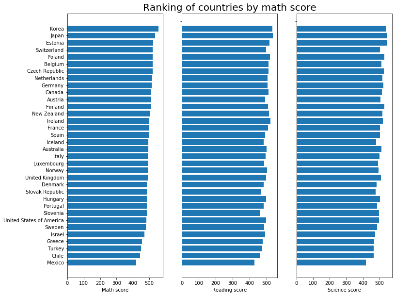

```python
pisa_oecd['PV1MATH'] = pisa_oecd['PV1MATH'].astype(float)
pisa_oecd['PV1READ'] = pisa_oecd['PV1READ'].astype(float)
pisa_oecd['PV1SCIE'] = pisa_oecd['PV1SCIE'].astype(float)

df_scores = pisa_oecd.iloc[:, np.r_[:5, 500, 540, 545]]
df_scores = df_scores.groupby('CNT').mean()
df_scores = df_scores.reset_index()
df_scores_chart = df_scores.sort_values('PV1MATH')

plt.figure(figsize=[12,10])

plt.subplot(1, 3, 1)
plt.barh('CNT', 'PV1MATH', data=df_scores_chart)
plt.xlabel('Math score');

plt.subplot(1, 3, 2)
plt.barh('CNT', 'PV1READ', data=df_scores_chart)
plt.xlabel('Reading score')
plt.yticks("")
plt.title('Ranking of countries by math score', fontsize=20);

plt.subplot(1, 3, 3)
plt.barh('CNT', 'PV1SCIE', data=df_scores_chart)
plt.xlabel('Science score')
plt.yticks("");
```

## Math lessons influence math scores?

Unexpectedly, there is no evidence that math lessons positively influence math scores. Therefore, the countries should investigate the teaching methodologies to understand the reasons behind this conclusion.

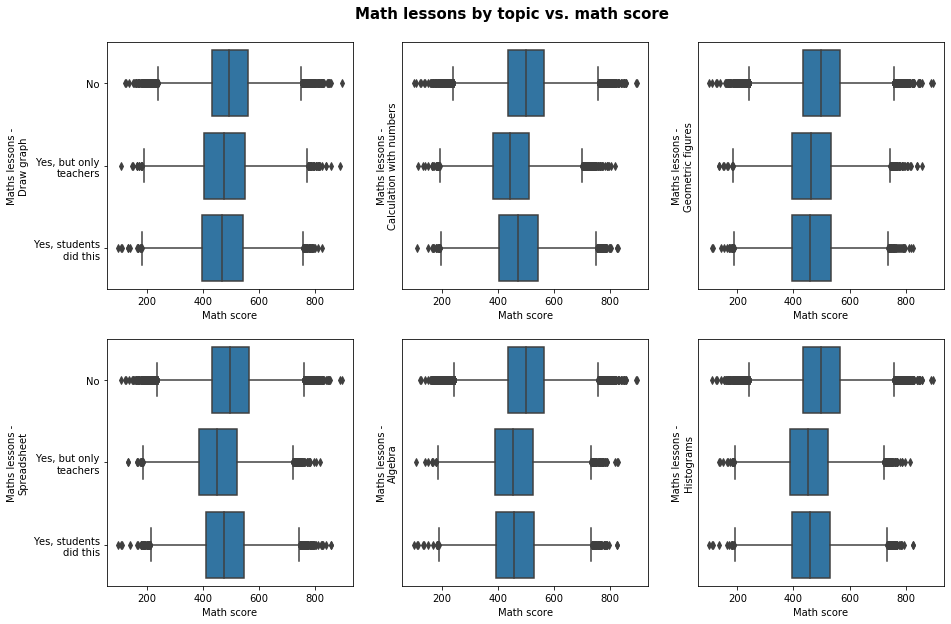

```python
df_math_lessons = pisa_oecd.iloc[:, np.r_[332:339, 500]]
df_math_lessons = df_math_lessons.reset_index()
df_math_lessons.head()

list_of_vars = ["IC11Q0{}".format(i) for i in range(1,7)]
answer_order = ['No', 'Yes, but only the teacher demonstrated this ', 'Yes, students did this']
for var in list_of_vars:
    df_math_lessons[var] = pd.Categorical(df_math_lessons[var],
                                    categories=answer_order,
                                    ordered = True)
plt.figure(figsize=[15,10])
base_color = sb.color_palette()[0]

plt.subplot(2, 3, 1)
sb.boxplot(data=df_math_lessons, y='IC11Q01', x='PV1MATH', color=base_color)
plt.ylabel('Maths lessons -\nDraw graph')
plt.yticks([0, 1, 2], ['No', 'Yes, but only\nteachers', 'Yes, students\ndid this'])
plt.xlabel('Math score');

plt.subplot(2, 3, 2)
sb.boxplot(data=df_math_lessons, y='IC11Q02', x='PV1MATH', color=base_color)
plt.ylabel('Maths lessons -\nCalculation with numbers')
plt.yticks([], [])
plt.xlabel('Math score');

plt.subplot(2, 3, 3)
sb.boxplot(data=df_math_lessons, y='IC11Q03', x='PV1MATH', color=base_color)
plt.ylabel('Maths lessons -\nGeometric figures')
plt.yticks([], [])
plt.xlabel('Math score');

plt.subplot(2, 3, 4)
sb.boxplot(data=df_math_lessons, y='IC11Q04', x='PV1MATH', color=base_color)
plt.ylabel('Maths lessons -\nSpreadsheet')
plt.yticks([0, 1, 2], ['No', 'Yes, but only\nteachers', 'Yes, students\ndid this'])
plt.xlabel('Math score');

plt.subplot(2, 3, 5)
sb.boxplot(data=df_math_lessons, y='IC11Q05', x='PV1MATH', color=base_color)
plt.ylabel('Maths lessons -\nAlgebra')
plt.yticks([], [])
plt.xlabel('Math score');

plt.subplot(2, 3, 6)
sb.boxplot(data=df_math_lessons, y='IC11Q06', x='PV1MATH', color=base_color)
plt.ylabel('Maths lessons -\nHistograms')
plt.yticks([], [])
plt.xlabel('Math score');

plt.suptitle('Math lessons by topic vs. math score', y=0.93, fontsize=15, weight='bold');
```

## Math vs. Reading scores by country

As expected, countries with higher scores in math also have higher scores in reading. There is a high positive correlation between both variables.

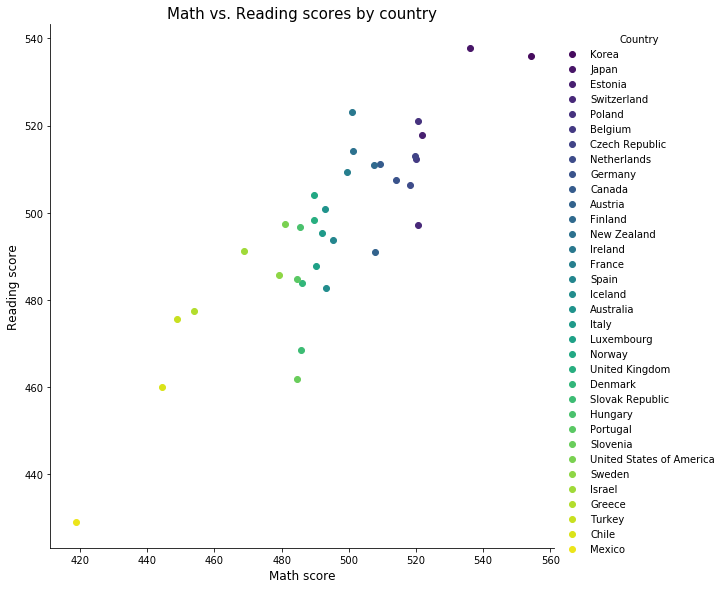

```python
df_scores_chart1 = df_scores_chart.sort_values('PV1MATH', ascending=False)
ss = sb.FacetGrid(data=df_scores_chart1, hue='CNT', height=8, palette='viridis');
ss.map(plt.scatter, 'PV1MATH', 'PV1READ')
ss.add_legend(title='Country')
plt.xlabel('Math score', fontsize=12)
plt.ylabel('Reading score', fontsize=12)
plt.title('Math vs. Reading scores by country', fontsize=15);
```